# **Gene-culture** coevolution

Thomas Huet

Gene-culture coevolution is one of the main challenge of evolutionnary archaeology. Study of aDNA will permit to respond to the question: [‘*Who ?*’](https://github.com/zoometh/thomashuet/blob/main/README.md#statements).

It will permit to define the genetic identity of the social groups. For example, and schematically, the [hg U5](https://sites.google.com/view/haplotree-info/home/mtdna-u5) is typical of last hunter-gatherers/Mesolithics and the [hg N1a](https://sites.google.com/view/haplotree-info/home/y-dna-n) is typical of early farmers. In Eastern and Northern Europe, despite various material exchanges, few admixtures between early farmers farmers and indigenous hunter-gatherers have been observed. Mesolithics could have backed up to West Europe, the westernmost part of the Eurasian continent, and admixture could be more frequent in the West. In the middle Rhine valley, last hunter-gatherers populations have probably played a role in the Michelsberg cultural affirmation (Beau et al. 2017) and such interrogations also exist for the development of Megalithism along the Atlantic shore (Vincent and Emmanuel 2018). Genetic data acquired during INTERACT investigation will permit to precise elements to answer these questions. In addition to human societies, aDNA studies will also be useful to characterize animal and vegetal species (e.g. new breeds). Genetic analysis permit to evaluate populations (dis)similarities. The neutral hypothesis (H<sub>0</sub>) is that there is a population continuity with few random genetic drifts. Single-nucleotide polymorphisms (SNPs) are stable and good proxys to evaluate the (dis)similarities between populations. On the base of their study, H<sub>0</sub> can be rejected (H<sub>1</sub> accepted) and factors like mutation, selection and migration can be supposed. At the time scale we investigate, only the migration factor could explain observed changes in the genetic of Europeans. There exist various methods to measure differences between populations and to distinguish groups of populations. Proximities among pairwise groups can be evaluated by the comparison of their genetic distance (F<sub>ST</sub> matrix) (Hervella et al. 2015). The determination of groups (e.g. indigenous, immigrants) is mostly based on the study of the SNPs or discrete hg frequencies (Bramanti et al. 2009). Similarities will be computed with Analysis of Molecular Variance (AMOVA), genetic mapping (e.g. phylogenetic trees, haplotype network, median-joining network) and cluster analysis (multidimensional scaling, dendrogram, etc.). All the data will be proceed with [ape](https://cran.r-project.org/web/packages/ape/index.html), [pegas](https://cran.r-project.org/web/packages/pegas/index.html), or any appropriate R packages.

# Ancient mtDNA database

The mitochondrial DNA (mtDNA) can be download from the [Ancient mtDNA database](https://amtdb.org/records/) of published mitochondrial sequences coming from the ancient DNA samples (aDNA). There is mtDNA datasets: data and metadata

## mtDNA data

FASTA format is a text-based format for representing either nucleotide sequences or peptide sequences, in which base pairs or amino acids are represented using single-letter codes. A sequence in FASTA format begins with a single-line description, followed by lines of sequence data. FASTA formats can be read with the phylotools package. First identifiers are:

```
## RISE509
## RISE510
## RISE511
## RISE507
## RISE508
## I0707
## I0708
## I0709
## I0736
## I0744
```

The identifier is a unique key which allow to join the second dataset, metadata

## mtDNA metadata

The mtDNA makes it possible to trace the maternal line. It passes from the mother to her children (of both sexes). The metadata file mtdb_metadata.csv is downloaded from the [Ancient mtDNA database](https://amtdb.org/records/). The current metadata format is .csv

Table 1: aDNA metadata sample

| identifier | alternative_identifiers | country | continent | region | culture | epoch | group | comment | latitude | longitude | sex | site | site_detail | mt_hg | ychr_hg | year_from | year_to | date_detail | bp | c14_lab_code | reference_names | reference_links | reference_data_links | c14_sample_tag | c14_layer_tag | avg_coverage | sequence_source | ychr_snps |
| --- | --- | --- | --- | --- | --- | --- | --- | --- | --- | --- | --- | --- | --- | --- | --- | --- | --- | --- | --- | --- | --- | --- | --- | --- | --- | --- | --- | --- |
| Bt_2 | Bt_2* | Russia | Asia | Altai | Pazyryk | Iron Age | IAAL | Russian Altai (Chuya) | 50.2000 | 87.7000 | U | Borotal 2 |  | U2e2a |  | -400 | -300 | 400-300 BCE |  |  | Unterländer et al. 2017 | https://doi.org/10.1038/ncomms14615 | https://www.ebi.ac.uk/ena/data/view/PRJEB18686 | 0 | 1 | 0.00 | bam |  |
| AED_249 | SAMEA104354385 | Germany | Europe | central Europe | Germany_EMA | Middle Ages | MAGe |  | 48.2924 | 11.9053 | M | Altenerding - Klettham | spatha, belt, bag, vessel, glass | T2c1d1a |  | 460 | 510 | 460 – 510 AD |  |  | Veeramah et al. 2018 | https://doi.org/10.1073/pnas.1719880115 | https://www.ebi.ac.uk/ena/data/view/SAMEA104354379 | 0 | 1 | 263.83 | bam |  |
| I0112 | QUEXII6 | Germany | Europe | central Europe | Bell Beaker | Copper Age | BBC |  | 51.7900 | 11.1400 | F | Quedlinburg | Site IX | H13a1a2 |  | -2457 | -2142 | 2457-2142 calBCE (3820±42 BP, Erl-7038) | 3820±42 | Erl-7038 | Haak et al. 2015 | https://dx.doi.org/10.1038/nature14317 | https://www.ebi.ac.uk/ena/data/view/PRJEB8448 | 1 | 0 | 0.00 | <NA> |  |

It counts 2426 samples and 29 columns.

# Cross analysis

Cross analysis of mtDNA haplogroup aDNA, cultures and radiocarbon dates

## mtDNA *and* culture

Two fields give direct insights on the cultural membership of the skeleton. The field ‘culture’ counts 252 distinct cultures. The field ‘epoch’ is more generic and counts 14 distinct epoch.

```r
df.MesoNeo <- df %>%
  # select(selected.fields) %>%
  filter(epoch == 'Mesolithic' | epoch == 'Neolithic') %>%
  filter(latitude < 46 & latitude > 36) %>%
  filter(longitude > -6 & longitude < 22.5)
MNcultures <- as.data.frame(table(df.MesoNeo$culture),
                            stringsAsFactors = F)
MNcultures <- MNcultures %>%
  filter(Freq > 1)
unicums <- MNcultures %>% filter(Freq == 1) # get unicums
```

The new dataset counts 124 samples and 19 distinct cultures. :

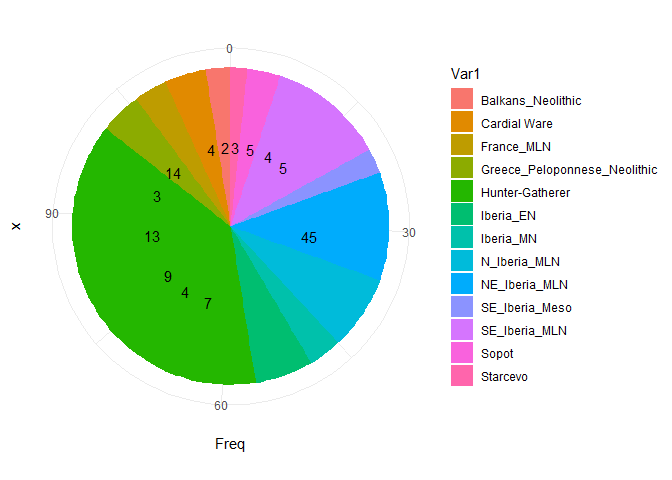

Map the dataset with sample’s haplogroup colored in red and the culture is colored in orange

[interactive chart not shown]

Figure 1: Cleaned [Ancient mtDNA database](https://amtdb.org/records/) using RShiny and Leaflet in R

A simple manner to see how mtDNA hg and cultures are correlated one with another consist in creating a graph drawing (a 2-mode graph) with the [igraph](https://cran.r-project.org/web/packages/igraph/index.html) package

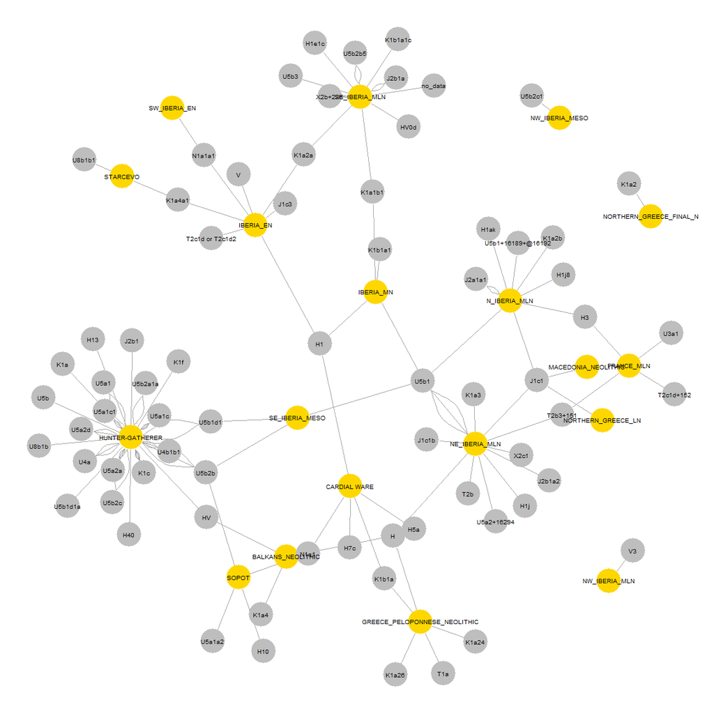

### Resume

Gene-culture coevolution needs to be refined. Here, as stated, data come from two distinct periods: Mesolithic and Neolithic. Maybe the cultural membership of mtDNA sample can be discussed, the time-rank could be precised, etc.

## mtDNA *and* radiocarbon dates

We will use the metadata .csv file to join the sample identifiers with the radiocarbon dates. These latter have a unique laboratory number [LabCode](https://zoometh.github.io/C14/neonet/#mf.labcode). This premit to associate the mtDNA sample with the radiocarbon date. To be easier to reuse for gene-date analysis, the dataset needs to be cleaned keeping interesting fields and removing samples with typo errors (like `df$longitude > 90`)

```r
selected.fields <- c("identifier", "mt_hg", "site", "culture", "epoch", "bp", "c14_lab_code", "longitude", "latitude", "reference_names", "reference_links")
n.samples <- nrow(df)
df <- df %>%
  select(selected.fields) %>%
  filter(longitude >= -90 & longitude <= 90) %>%
  filter(latitude >= -90 & latitude <= 90)
```

[output not shown]

The dataset has 2337 samples (-89 samples have coordinates errors). There’s 11 columns. The dataset can be spacialized with Leaflet

[interactive chart not shown]

(#fig:map_notclean)Cleaned [Ancient mtDNA database](https://amtdb.org/records/) using RShiny and Leaflet in R

The selected samples are those associated to radiocarbon dates, so empty values are removed. The radicarbon field ‘bp’ is not strictly formatted, a text editio has to be done with regular expressions (*regex*). by splitting the BP and SD values currently in the ‘bp’ field (split on ‘±’).

```r
df <- df %>%
  filter(bp != "" & !is.na(bp))  %>%
  filter(str_detect(bp, "±"))  %>%
  filter(!str_detect(bp, "BP|and"))

bps <- unlist(sapply(df$bp,
                     function(x) strsplit(x, "±")),
              use.names = FALSE)
mat <- matrix(bps, ncol=2, byrow=TRUE)
df$c14bp <- mat[, 1]
df$c14sd<- mat[, 2]
df$bp <- NULL
```

Now the new dataset has 979 samples and looks like:

Table 2: aDNA metadata sample

| identifier | mt_hg | site | culture | epoch | c14_lab_code | c14bp | c14sd | longitude | latitude | reference_names | reference_links |
| --- | --- | --- | --- | --- | --- | --- | --- | --- | --- | --- | --- |
| arm12 | J1d6 | Sotk 1 | Armenian | Middle Ages |  | 1242 | 39 | 45.86000 | 40.20000 | Margaryan et al. 2017 | https://doi.org/10.1016/j.cub.2017.05.087 |
| I4553 | U5a1c | Zvejnieki | Hunter-Gatherer | Mesolithic | PSUAMS-2838 | 6470 | 25 | 25.13000 | 56.28000 | Mathieson et al. 2018 | https://dx.doi.org/10.1038/nature25778 |
| OBKR_95 | V1a | Königsbrunn, Obere Kreuzstraße | Early Bronze Age | Bronze Age | MAMS-18909 | 3608 | 23 | 10.87816 | 48.26652 | Knipper et al. 2017 | https://doi.org/10.1073/pnas.1706355114 |
| I10866 | K1b2a | Empúries, Girona, Catalonia | Roman | Classical Age |  | 2005 | 15 | 3.10830 | 42.13330 | Olalde et al. 2019 | https://doi.org/10.1126/science.aav4040 |
| I1390 | X2b4a | Sierentz, Les Villas d’Aurele, Haut-Rhin | Bell Beaker | Copper Age | Poz-41227 | 3910 | 35 | 7.45000 | 47.65000 | Olalde et al. 2018 | https://dx.doi.org/10.1038/nature25738 |
| DA86 | C4b1 | Kurgan nr. 16, Boz-Adyr | Turk | Middle Ages | UBA-31204 | 1582 | 42 | 76.96556 | 42.07611 | de Barros Damgaard et al. 2018 | https://doi.org/10.1038/s41586-018-0094-2 |

The dataset can be spatialized. The mtDNA haplogroup is colored in red. The LabCode is colored in green

[interactive chart not shown]

(#fig:map_ok)Cleaned [Ancient mtDNA database](https://amtdb.org/records/) using RShiny and Leaflet in R

With their unique LabCode, the dates can be easily [calibrated](https://neolithic.shinyapps.io/AbsoluteDating/#Applications) and connected to existing [databases](https://neolithic.shinyapps.io/AbsoluteDating/#Databases)

# Gene-culture coevolution representation

The classical issue on gene-culture coevolution topic – to challenge the opposite ‘demic diffusion’ (i.e. immigration) and ‘trait-adoption’ (i.e. acculturation) models – is purely theoretical: at the same time the population grew, both demic and cultural diffusions occurred. As said, horizontal transmission (exchanges between two or more societies) has taken a growing importance in course of the Neolithic. Transmissions can be represented with a dendrogram when vertical (i.e diachronic, e.g. genetic transmission) or a network when horizontal (i.e contemporary, e.g. trade network). A phylogenetic tree will show a tree-like history (vertical) while a cultural tree will be more anastomosed (i.e. reticulated), showing more synchronous divergences (Gray, Bryant, and Greenhill 2010). To measure the coefficient of these horizontal interconnections we will employ the NeighborNet algorithm of [phangorn](https://cran.r-project.org/web/packages/phangorn/index.html). This algorithm is based on the neighbor-joining method, it calculates the statistics of D-score and its derivative Q-residual (a Q-residual=0 is a tree, a Q-residual=1 is fully reticulated). Trees can be rooted (i.e. the ancestor will be identify) using appropriate algorithms depending on assumptions on evolution dynamics: weighted or unweighted pair-group arithmetic average (WPGMA or UPGMA) for example. The symbology of phylogenetic trees, networks, maps and other graphs will be managed with graphical grammar (e.g. [ggplot](https://cran.r-project.org/web/packages/ggplot2/index.html))

# Gene-culture coevolution simulation

Once *facts* established and patterns recognized, spatio-temporal *scenarios* will also be proposed. ABM permits to simulated interactions between local entities (agents or patches) within an environment (the so-called ‘world’). For historical sciences, it permits to infer past mechanisms (simulated data) from the observation of the present situation (observed data). In archaeology, ABM had been appropriately employ, for example, to explain the LBK Neolithic diffusion(Dubouloz, Bocquet-Appel, and Moussa 2017). LBK diffusion is almost continuous and seems to correspond to the so-called ‘ideal despotic distribution’ model (IDD model): after a village scission and a migration, LBK families, or groups, founded a new settlement in the best soils (‘best patches’)(Shennan 2007). The village scission is probably triggered by a high consumption/production (C/P) ratio: a population growth and a correlative decreasing productivity for food production (Dubouloz, Bocquet-Appel, and Moussa 2017). This processes are also visible in the LBK village organization. This latter shows two kinds of houses: small houses with ceramic innovations, craft activities, importance of hunting products, few grinding tools, without granaries, etc., and big houses with traditional ceramics, ox dominant, concentration of grinding tools, granaries, etc. The small houses are considered to be those of the new incomers into the village, while big houses correspond to more ancient inhabitants and lineages (Borojevic 2001)(Gomart et al. 2015). These observations will be further developed as part of the ANR Homes[^3]. To be meaningfully conducted on Neolithic contexts, ABM necessarily needs to be simple and grounded on robust observations: its task is to enlighten emerging complex structures from simple interactions and models by identifying threshold effects (e.g. agriculture capabilities, estimated population size). Our ABM will be based on aDNA data and cultural traits analyses. Agents (*turtles* in NetLogo) and patches (field units in the ‘world’) will be social groups, villages, agrarian units, family lineage, etc. We will employ, and develop, existing mathematical models of interactions: between different agents (e.g. gravity models), or between agent and its environment (e.g. GLUES model (Lemmen, Gronenborn, and Wirtz 2011)). Considering populations’ size and demography, summed radiocarbon probability distributions (SRPD), settlement studies, and analyses of funeral domain (e.g. necropolis, average age of death) would be used as a proxy. Map algebra, taking into account nature of the soil, average of precipitation, temperature and cloudiness, will permit to infer the agriculture capabilities of patches. By programming simulations with different inputs and models, we will test scenarios of historical developments to find the most likely to explain observed regularities. For each type of simulation the definition of the region of interest, different levels of interactions, rules of adaptation and emergence, models, types of statistical outputs, etc. will be done respecting the Overview, Design concepts, and Details (ODD) protocol. A particular interest will be put on the study of the time dimension.

# References

Beau, Alice, Maïté Rivollat, Hélène Réveillas, Marie-Hélène Pemonge, Fanny Mendisco, Yohann Thomas, Philippe Lefranc, and Marie-France Deguilloux. 2017. “Multi-Scale Ancient DNA Analyses Confirm the Western Origin of Michelsberg Farmers and Document Probable Practices of Human Sacrifice.” *PLOS ONE* 12 (July): e0179742. https://doi.org/10.1371/journal.pone.0179742.

Borojevic, Ksenija. 2001. “Architecture Et Société néolithique: L’unité Et La Variance de La Maison Danubienne. Anick Coudart 1998. Documents d’archéologie Française, No. 67. Edition de La Maison Des Sciences de l’homme,’ Paris. 239 Pp. 194 Figures, Tables, 2 Appendices, Footnotes, Bibliography, Abstract in French, English, and German. 265 FF (Paper), ISBN 2-7351-0637-3.” *American Antiquity* 66 (2): 377–78. https://doi.org/10.2307/2694617.

Bramanti, Barbara, Mark Thomas, W Haak, Martina Unterländer, Pia Jores, Kristiina Tambets, I Antanaitis-Jacobs, et al. 2009. “Genetic Discontinuity Between Local Hunter-Gatherers and Central Europe’s First Farmers.” *Science (New York, N.Y.)* 326 (October): 137–40. https://doi.org/10.1126/science.1176869.

Dubouloz, Jérôme, Jean-Pierre Bocquet-Appel, and Richard Moussa. 2017. “Modélisation, Simulation Et Scénarios d’expérimentation : La Colonisation LBK de l’europe Tempérée (5550‑4950 Av.n.e.).” In, 315–37. Sidestone Press.

Gomart, Louise, Lamys Hachem, Caroline Hamon, François Giligny, and Michael Ilett. 2015. “Household Integration in Neolithic Villages: A New Model for the Linear Pottery Culture in West-Central Europe.” *Journal of Anthropological Archaeology* 40 (December): 230–49. https://doi.org/10.1016/j.jaa.2015.08.003.

Gray, Russell D., David Bryant, and Simon J. Greenhill. 2010. “On the Shape and Fabric of Human History.” *Philosophical Transactions of the Royal Society B: Biological Sciences* 365 (1559): 3923–33. https://doi.org/10.1098/rstb.2010.0162.

Hervella, Montse, Mihai Rotea, Neskuts Izagirre, Mihai Constantinescu, Santos Alonso, Ioana Mihai, Catalin Lazar, et al. 2015. “Ancient DNA from South-East Europe Reveals Different Events During Early and Middle Neolithic Influencing the European Genetic Heritage.” *PLoS ONE* 10 (June): e0128810. https://doi.org/10.1371/journal.pone.0128810.

Lemmen, Carsten, Detlef Gronenborn, and Kai W. Wirtz. 2011. “A Simulation of the Neolithic Transition in Western Eurasia.” *Journal of Archaeological Science* 38 (12): 3459–70. https://doi.org/https://doi.org/10.1016/j.jas.2011.08.008.

Shennan, S. J. 2007. “The Model-Based Archaeology of Socionatural Systems.” In, edited by T Kohler and SE Van der Leeuw, The spread of farming into Central Europe and its consequences: evolutionary models:141–56. School of American Research Press.

Vincent, Ard, and Mens Emmanuel. 2018. “Le mégalithisme : Regards Croisés Entre Mondes Atlantique Et méditerranéen in j. Guilaine Et d. Garcia Eds. La Protohistoire de La France.” In, 79–93. ed. Hermann.